# Assignment 4

Fuyu

October 28, 2020

## Summary

- This is an app to predict the horsepower in dataset mtcars.
- Basiclly, we will use only miles per gallon to predict the horsepower.
- Also, in the sidebar, you can choose to add the number of cylinders in to the model, and to predict the horsepower.
- The data used in the app comes from mtcars.

```r
library(kableExtra)
summary(mtcars[, c("mpg", "cyl", "hp")])
```

```
      mpg             cyl              hp
 Min.   :10.40   Min.   :4.000   Min.   : 52.0
 1st Qu.:15.43   1st Qu.:4.000   1st Qu.: 96.5
 Median :19.20   Median :6.000   Median :123.0
 Mean   :20.09   Mean   :6.188   Mean   :146.7
 3rd Qu.:22.80   3rd Qu.:8.000   3rd Qu.:180.0
 Max.   :33.90   Max.   :8.000   Max.   :335.0
```

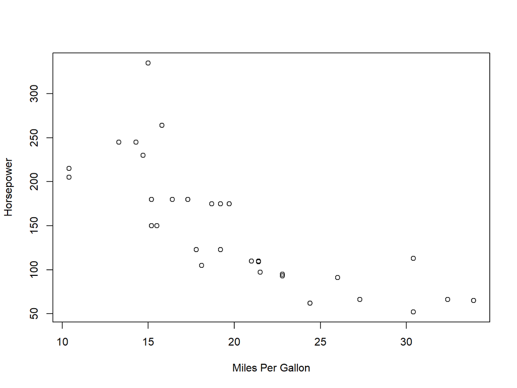

```r
plot(mtcars$mpg, mtcars$hp, xlab = "Miles Per Gallon", ylab = "Horsepower")
```

## Only use miles per gallon

- In this situation, please don't choose *Include number of cylinders*.
- In the plot, you will see a red curve.
- You can change the value of miles per gallon in the sidebar. The value and the predicted horse power will be shown on the right-upper corner in the graph.
- Attention, in this situation, it will change nothing when you change the number of cylinders.

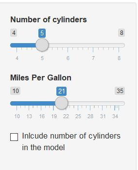

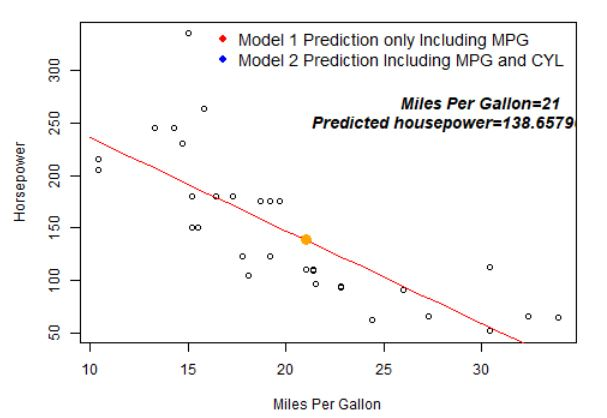

## Only use miles per gallon

- Change the value of miles per gallon.

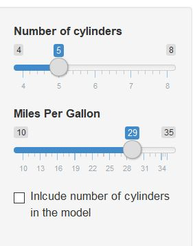

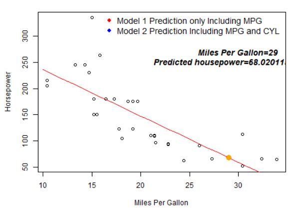

- Change the number of cylinders.

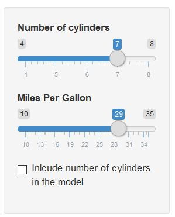

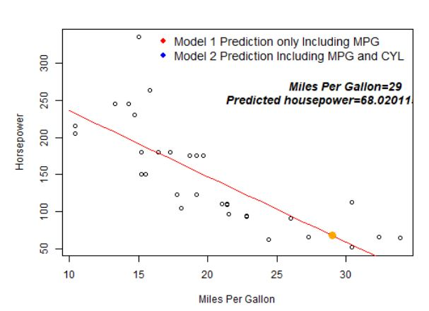

## Include both miles per gallon and the number of cylinders

- In this situation, please choose *Include number of cylinders*.
- In the plot, you will see a blue curve.
- You can change the value of miles per gallon and the number of cylinders in the sidebar.
- Attention, in this situation, both miles per gallon and the number of cylinders will determine the predicted horsepower.

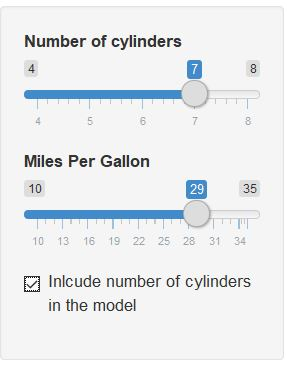

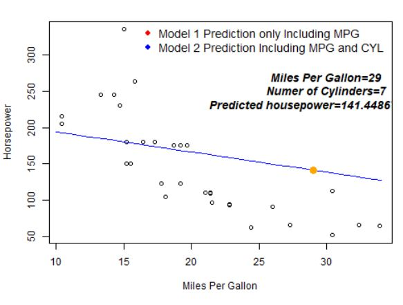